# 公历八月

2018年，九月01日

## 一、清醒时间安排情况

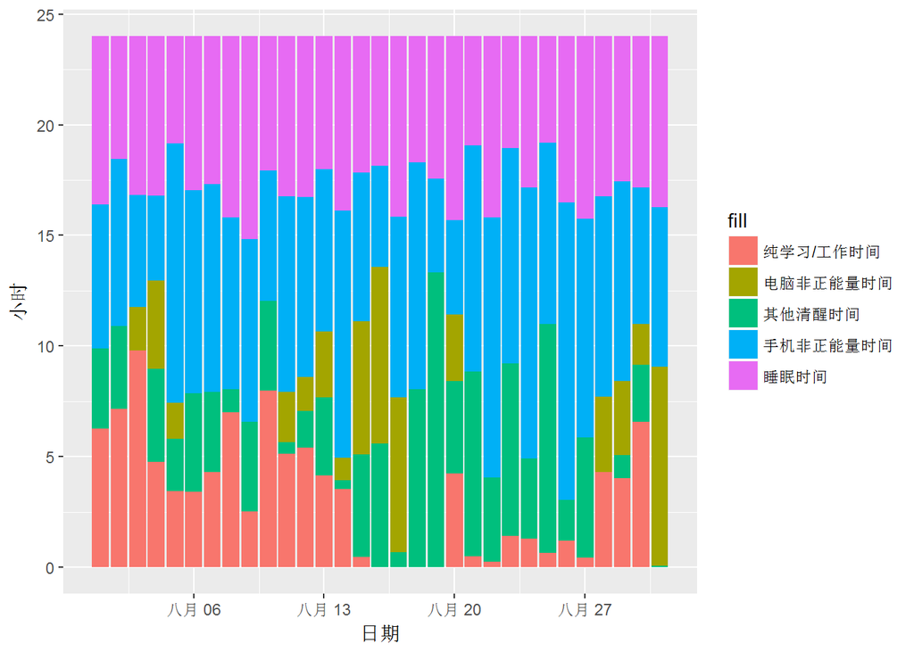

图中反映了本期31天每日时间的构成及其变化，

启动时间，反映了本人自起床开始到做本日第一件事，平均要花3.04小时，占全部清醒时间的17.73%；

纯学习时间，平均为3.23小时，占清醒时间比重为18.84%；

手机非正能量时间每天为8.25小时,占清醒时间比重为48.13%；

电脑非正能量时间平均每天为1.85小时,占清醒时间比重为10.79%。

## 二、睡眠状况

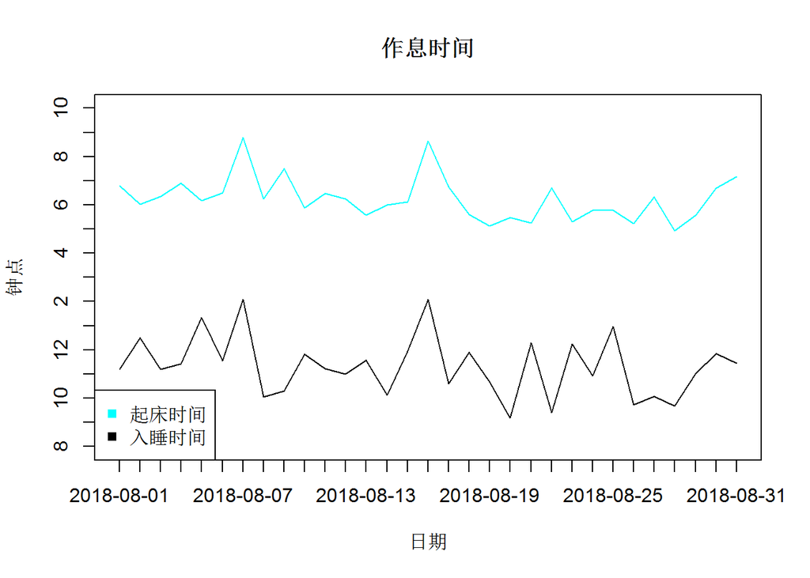

“作息时间”图反映了本期本人每日的入睡与起床时间，在这一期间，本人平均每天11点20分入睡，6点15分起床，睡眠时间平均为6.85小时；

入睡时间和起床时间有显著的相关关系，相较而言，起床时间的波动要比入睡时间更小。

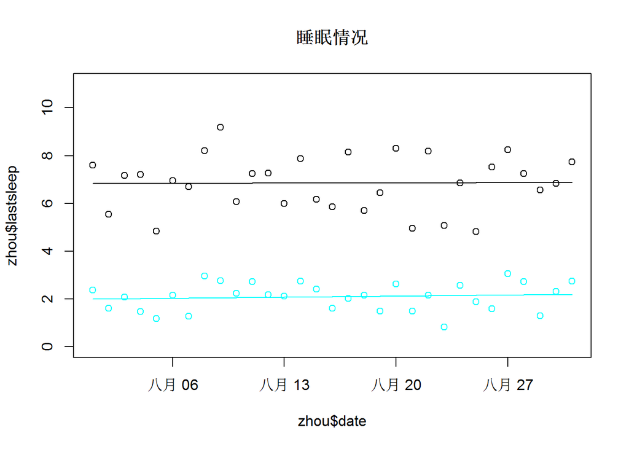

从线性趋势上看，总睡眠时间无明显变化，深睡眠时间无明显变化，睡眠质量向好发展。

## 三、学习状况

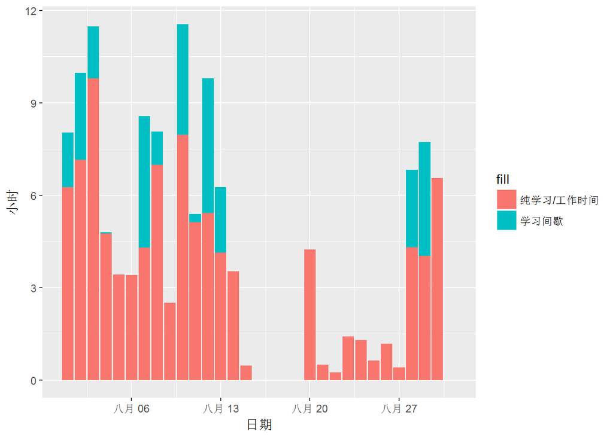

本期平均每日毛学习/工作时间为4.14小时，呈显著减少趋势；

纯学习/工作时间为3.23小时，呈显著减少趋势，用于学习的时间达到了平均水平；

时间利用比为1.28，处于适度轻松的学习状态。

### 核心时间

核心时间指的是完全由自主学习构成，推动个人发展的时间；本期平均每周的核心时间为4.48小时，占纯学习时间的17.81%；

就今年而言，本期核心时间较平常要少。

## 四、娱乐时间

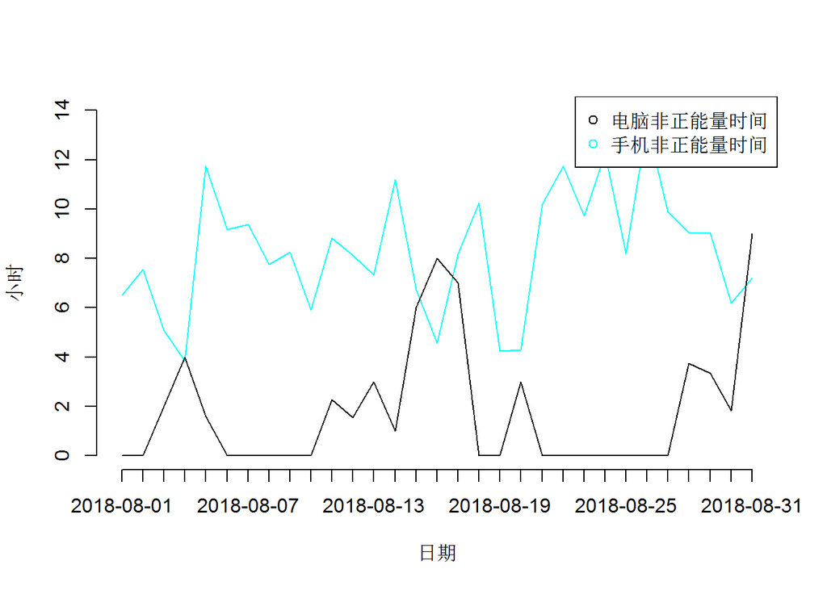

平均每日使用手机时间为8.5小时，本期内无明显变化；其中非正能量时间8.25小时，本期内无明显变化，与纯学习时间 没有显著的相关关系。

平均每日使用电脑时间为1.85小时；其中非正能量时间为1.85小时，本期内无明显变化，与纯学习时间 没有显著的相关关系。

两者之和 与纯学习时间 有显著的相关关系。